# Stroke Prediction

Anurag Nepal

2025-03-16

# Background

I wanted to see how well stroke occurrence can be predicted from patient demographics and health indicators, and which modeling choices matter for a rare event. The plan: compare eight classifiers across four preprocessing scenarios, with and without SMOTE for the class imbalance and with and without PCA, and judge each on AUC, accuracy, sensitivity, and specificity.

# Setup

The data is `healthcare-dataset-stroke-data.csv`, in this repo. One row per patient: age, gender, hypertension, heart disease, marital and work status, residence type, glucose level, BMI, smoking status, and the stroke indicator. Only about 5% of rows are strokes, so the imbalance drives most of the modeling decisions below.

## Exploratory analysis

```r
stroke_data = read.csv("healthcare-dataset-stroke-data.csv")
```

```r
glimpse(stroke_data)
```

```
## Rows: 5,110
## Columns: 12
## $ id                <int> 9046, 51676, 31112, 60182, 1665, 56669, 53882, 10434~
## $ gender            <chr> "Male", "Female", "Male", "Female", "Female", "Male"~
## $ age               <dbl> 67, 61, 80, 49, 79, 81, 74, 69, 59, 78, 81, 61, 54, ~
## $ hypertension      <int> 0, 0, 0, 0, 1, 0, 1, 0, 0, 0, 1, 0, 0, 0, 0, 1, 0, 1~
## $ heart_disease     <int> 1, 0, 1, 0, 0, 0, 1, 0, 0, 0, 0, 1, 0, 1, 1, 0, 1, 0~
## $ ever_married      <chr> "Yes", "Yes", "Yes", "Yes", "Yes", "Yes", "Yes", "No~
## $ work_type         <chr> "Private", "Self-employed", "Private", "Private", "S~
## $ Residence_type    <chr> "Urban", "Rural", "Rural", "Urban", "Rural", "Urban"~
## $ avg_glucose_level <dbl> 228.69, 202.21, 105.92, 171.23, 174.12, 186.21, 70.0~
## $ bmi               <chr> "36.6", "N/A", "32.5", "34.4", "24", "29", "27.4", "~
## $ smoking_status    <chr> "formerly smoked", "never smoked", "never smoked", "~
## $ stroke            <int> 1, 1, 1, 1, 1, 1, 1, 1, 1, 1, 1, 1, 1, 1, 1, 1, 1, 1~
```

```r
summary(stroke_data)
```

```
##        id           gender               age         hypertension
##  Min.   :   67   Length:5110        Min.   : 0.08   Min.   :0.00000
##  1st Qu.:17741   Class :character   1st Qu.:25.00   1st Qu.:0.00000
##  Median :36932   Mode  :character   Median :45.00   Median :0.00000
##  Mean   :36518                      Mean   :43.23   Mean   :0.09746
##  3rd Qu.:54682                      3rd Qu.:61.00   3rd Qu.:0.00000
##  Max.   :72940                      Max.   :82.00   Max.   :1.00000
##  heart_disease     ever_married        work_type         Residence_type
##  Min.   :0.00000   Length:5110        Length:5110        Length:5110
##  1st Qu.:0.00000   Class :character   Class :character   Class :character
##  Median :0.00000   Mode  :character   Mode  :character   Mode  :character
##  Mean   :0.05401
##  3rd Qu.:0.00000
##  Max.   :1.00000
##  avg_glucose_level     bmi            smoking_status         stroke
##  Min.   : 55.12    Length:5110        Length:5110        Min.   :0.00000
##  1st Qu.: 77.25    Class :character   Class :character   1st Qu.:0.00000
##  Median : 91.89    Mode  :character   Mode  :character   Median :0.00000
##  Mean   :106.15                                          Mean   :0.04873
##  3rd Qu.:114.09                                          3rd Qu.:0.00000
##  Max.   :271.74                                          Max.   :1.00000
```

BMI should be integer but is there as character.

```r
stroke_data$bmi=as.double(stroke_data$bmi)
summary(stroke_data)
```

```
##        id           gender               age         hypertension
##  Min.   :   67   Length:5110        Min.   : 0.08   Min.   :0.00000
##  1st Qu.:17741   Class :character   1st Qu.:25.00   1st Qu.:0.00000
##  Median :36932   Mode  :character   Median :45.00   Median :0.00000
##  Mean   :36518                      Mean   :43.23   Mean   :0.09746
##  3rd Qu.:54682                      3rd Qu.:61.00   3rd Qu.:0.00000
##  Max.   :72940                      Max.   :82.00   Max.   :1.00000
##
##  heart_disease     ever_married        work_type         Residence_type
##  Min.   :0.00000   Length:5110        Length:5110        Length:5110
##  1st Qu.:0.00000   Class :character   Class :character   Class :character
##  Median :0.00000   Mode  :character   Mode  :character   Mode  :character
##  Mean   :0.05401
##  3rd Qu.:0.00000
##  Max.   :1.00000
##
##  avg_glucose_level      bmi        smoking_status         stroke
##  Min.   : 55.12    Min.   :10.30   Length:5110        Min.   :0.00000
##  1st Qu.: 77.25    1st Qu.:23.50   Class :character   1st Qu.:0.00000
##  Median : 91.89    Median :28.10   Mode  :character   Median :0.00000
##  Mean   :106.15    Mean   :28.89                      Mean   :0.04873
##  3rd Qu.:114.09    3rd Qu.:33.10                      3rd Qu.:0.00000
##  Max.   :271.74    Max.   :97.60                      Max.   :1.00000
##                    NA's   :201
```

```r
stroke_counts = table(stroke_data$stroke)
stroke_counts_df = as.data.frame(stroke_counts)
stroke_counts_df$percentage = stroke_counts_df$Freq / sum(stroke_counts_df$Freq) * 100
colnames(stroke_counts_df) = c("stroke", "count", "percentage")
print(stroke_counts_df)
```

```
##   stroke count percentage
## 1      0  4861  95.127202
## 2      1   249   4.872798
```

Data imbalance so may have to augment the data.

```r
na_counts = colSums(is.na(stroke_data))
na_counts[na_counts > 0]
```

```
## bmi
## 201
```

```r
stroke_data = stroke_data[stroke_data$gender != "Other", ]
```

```r
categorize_age = function(age) {
  if (age >= 0 & age <= 1) {
    return('Infant')
  } else if (age > 1 & age <= 12) {
    return('Children')
  } else if (age > 12 & age < 20) {
    return('Teenager')
  } else if (age >= 20 & age <= 39) {
    return('Adult')
  } else if (age > 39 & age <= 59) {
    return('Middle Aged')
  } else {
    return('Senior')
  }
}

stroke_data$age_group = sapply(stroke_data$age, categorize_age)
unique(stroke_data$age_group)
```

```
## [1] "Senior"      "Middle Aged" "Adult"       "Children"    "Teenager"
## [6] "Infant"
```

```r
avg_bmi_by_group = aggregate(bmi ~ age_group + gender, data = stroke_data, FUN = mean)
colnames(avg_bmi_by_group) = c("age_group","gender","avg_bmi")
avg_bmi_by_group
```

| age_group | gender | avg_bmi |
| --- | --- | --- |
| Adult | Female | 29.68774 |
| Children | Female | 19.23281 |
| Infant | Female | 18.21250 |
| Middle Aged | Female | 31.40455 |
| Senior | Female | 29.90319 |
| Teenager | Female | 26.27750 |
| Adult | Male | 30.01599 |
| Children | Male | 19.67847 |
| Infant | Male | 18.43871 |
| Middle Aged | Male | 31.90985 |

[output cut: 2 more lines]

```r
# Keep the pre-imputation values. The group means above are computed on the
# full dataset, so this fill is for the EDA plots only. The modeling section
# redoes the imputation leakage-free (means from the training split only).
stroke_data$bmi_raw = stroke_data$bmi
stroke_data = merge(stroke_data, avg_bmi_by_group, by = c("age_group", "gender"), all.x = TRUE)
stroke_data$bmi = ifelse(is.na(stroke_data$bmi), stroke_data$avg_bmi, stroke_data$bmi)
stroke_data$avg_bmi = NULL
```

Used the average bmi for the age group and gender to fill in the bmi NA values for the exploratory plots below. Before modeling, the imputation is redone with group means from the training split only, so no test information leaks into training.

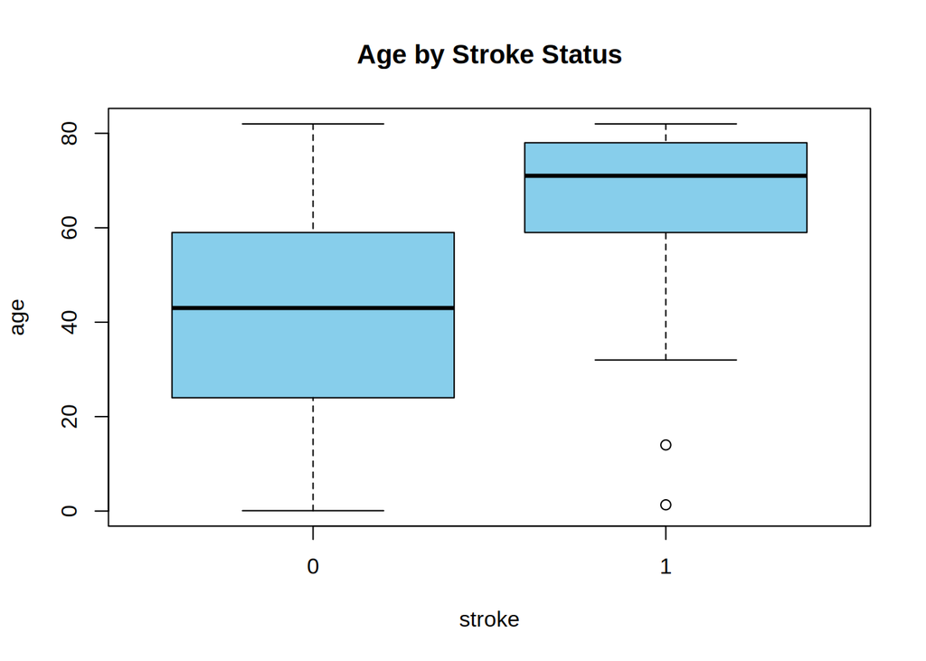

```r
boxplot(age ~ stroke, data = stroke_data, main = "Age by Stroke Status", col = "skyblue")
```

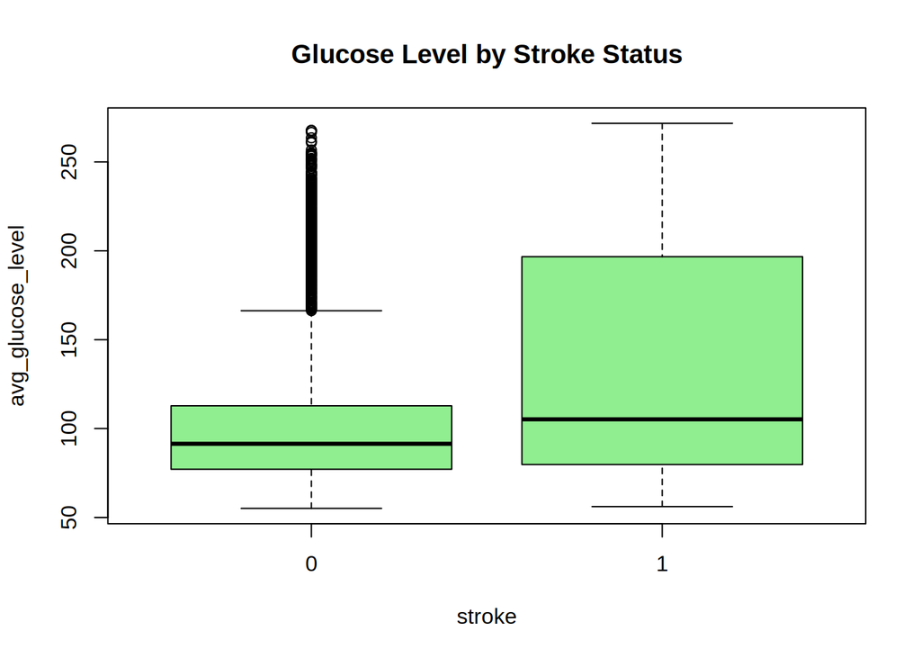

```r
boxplot(avg_glucose_level ~ stroke, data = stroke_data, main = "Glucose Level by Stroke Status", col = "lightgreen")
```

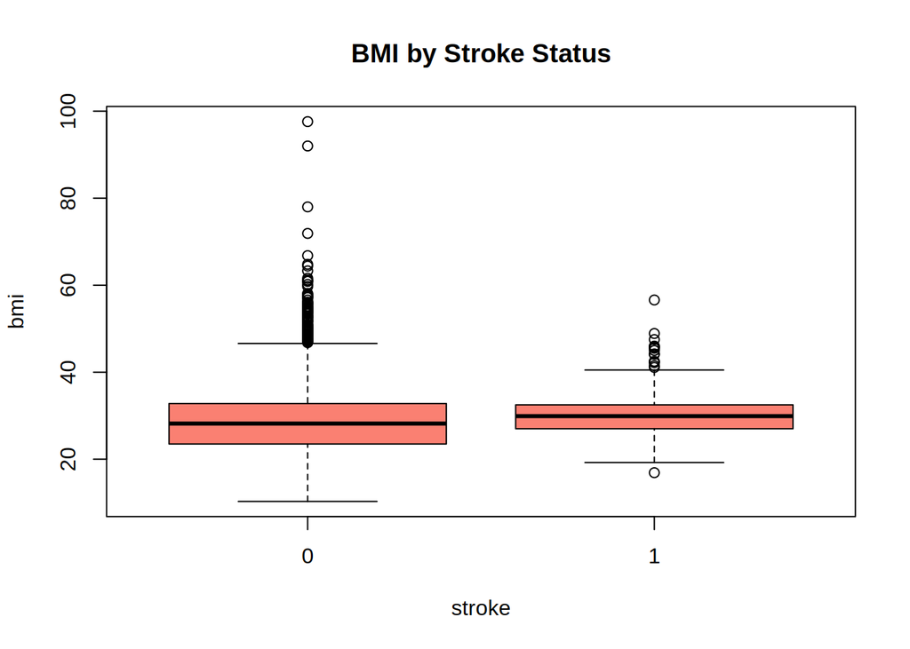

```r
boxplot(bmi ~ stroke, data = stroke_data, main = "BMI by Stroke Status", col = "salmon")
```

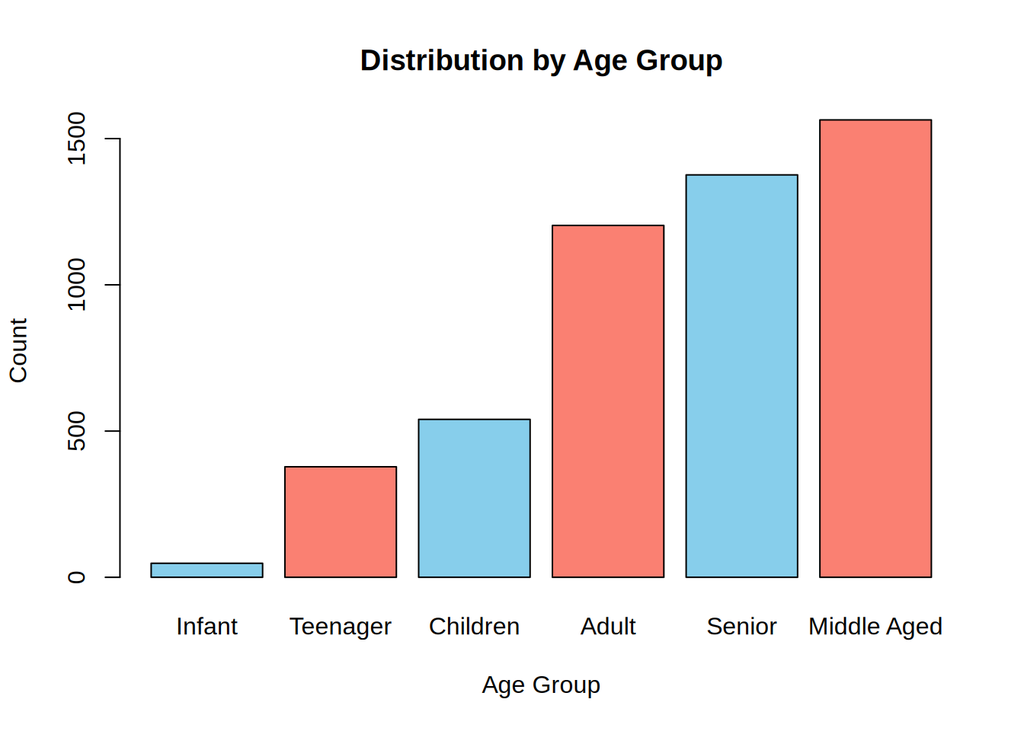

```r
barplot(sort(table(stroke_data$age_group)), beside = TRUE, main = "Distribution by Age Group",
        xlab = "Age Group", ylab = "Count", col = c("skyblue", "salmon"),
        legend = rownames(stroke_data$age_group))
```

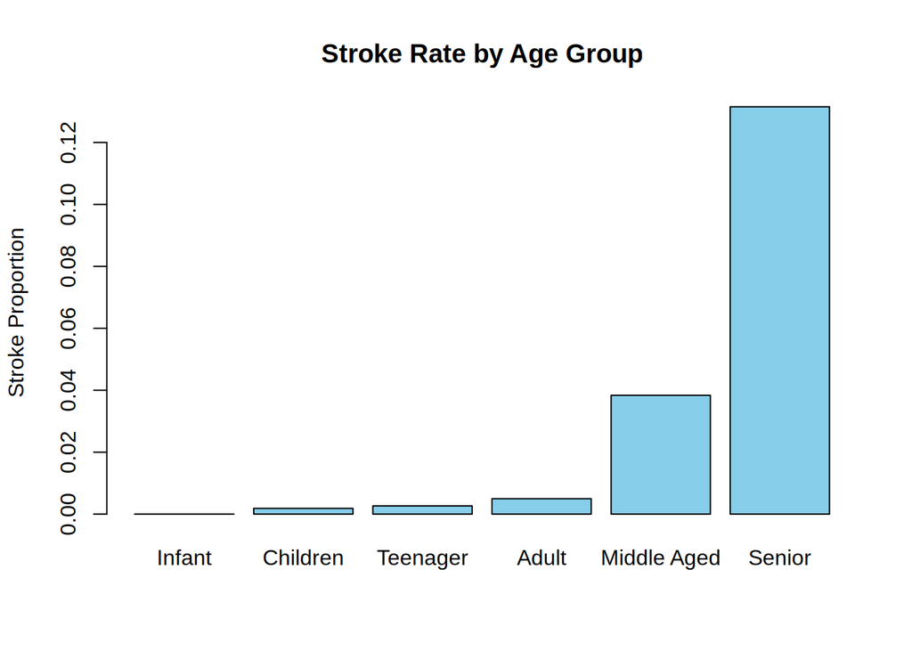

```r
age_group_stroke = prop.table((table(stroke_data$age_group, stroke_data$stroke)), margin = 1)
barplot(sort(age_group_stroke[, 2]), col = "skyblue", main = "Stroke Rate by Age Group", ylab = "Stroke Proportion")
```

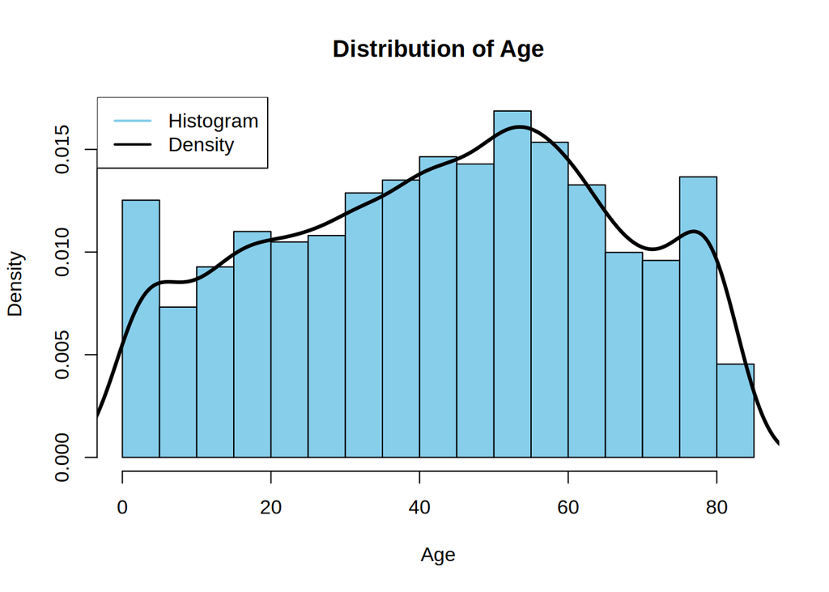

```r
hist(stroke_data$age, main = "Distribution of Age", xlab = "Age", col = "skyblue", breaks = 20, prob = TRUE)
lines(density(stroke_data$age, na.rm = TRUE), col = "black", lwd = 3)
legend("topleft", legend = c("Histogram", "Density"), col = c("skyblue", "black"), lwd = 2)
```

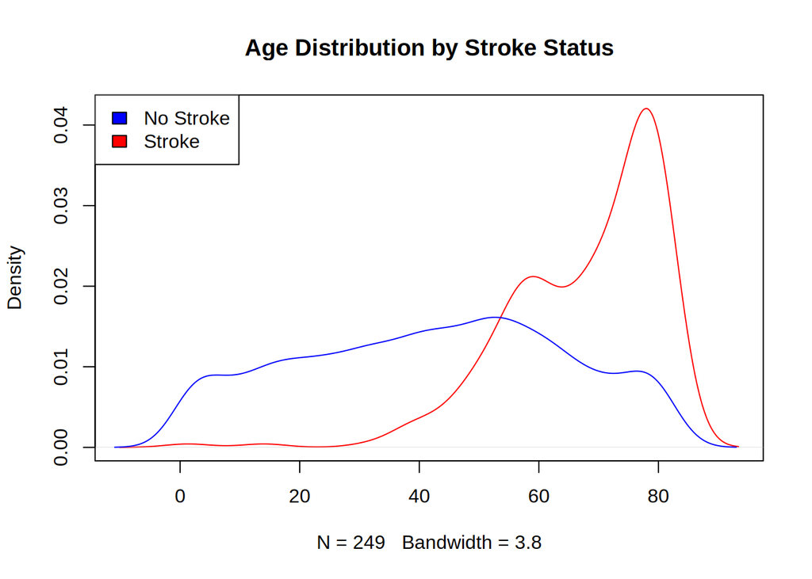

```r
plot(density(stroke_data$age[stroke_data$stroke == 1]), col = "red", main = "Age Distribution by Stroke Status")
lines(density(stroke_data$age[stroke_data$stroke == 0]), col = "blue")
legend("topleft", legend = c("No Stroke","Stroke"), fill = c("blue", "red"))
```

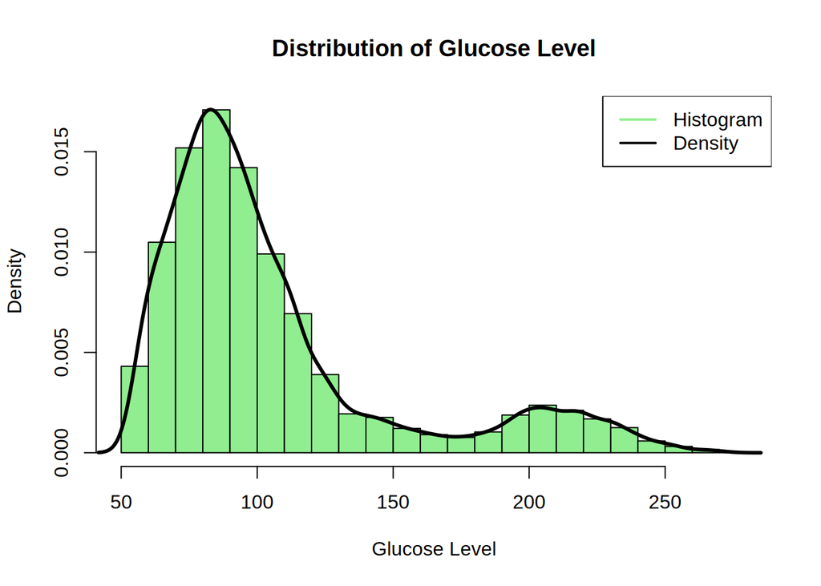

```r
hist(stroke_data$avg_glucose_level, main = "Distribution of Glucose Level", xlab = "Glucose Level", col = "lightgreen", breaks = 20,prob = TRUE)
lines(density(stroke_data$avg_glucose_level), col = "black",lwd=3)
legend("topright", legend = c("Histogram", "Density"), col = c("lightgreen", "black"), lwd = 2)
```

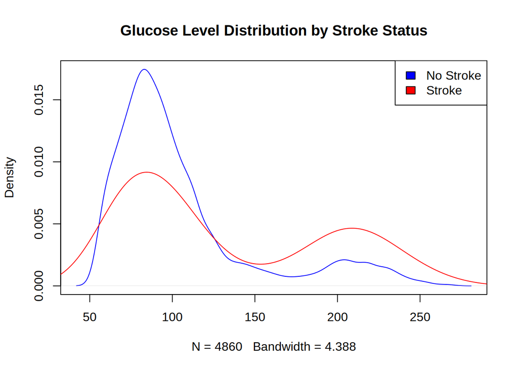

```r
plot(density(stroke_data$avg_glucose_level[stroke_data$stroke == 0]), col = "blue", main = "Glucose Level Distribution by Stroke Status")
lines(density(stroke_data$avg_glucose_level[stroke_data$stroke == 1]), col = "red")
legend("topright", legend = c("No Stroke","Stroke"), fill = c("blue", "red"))
```

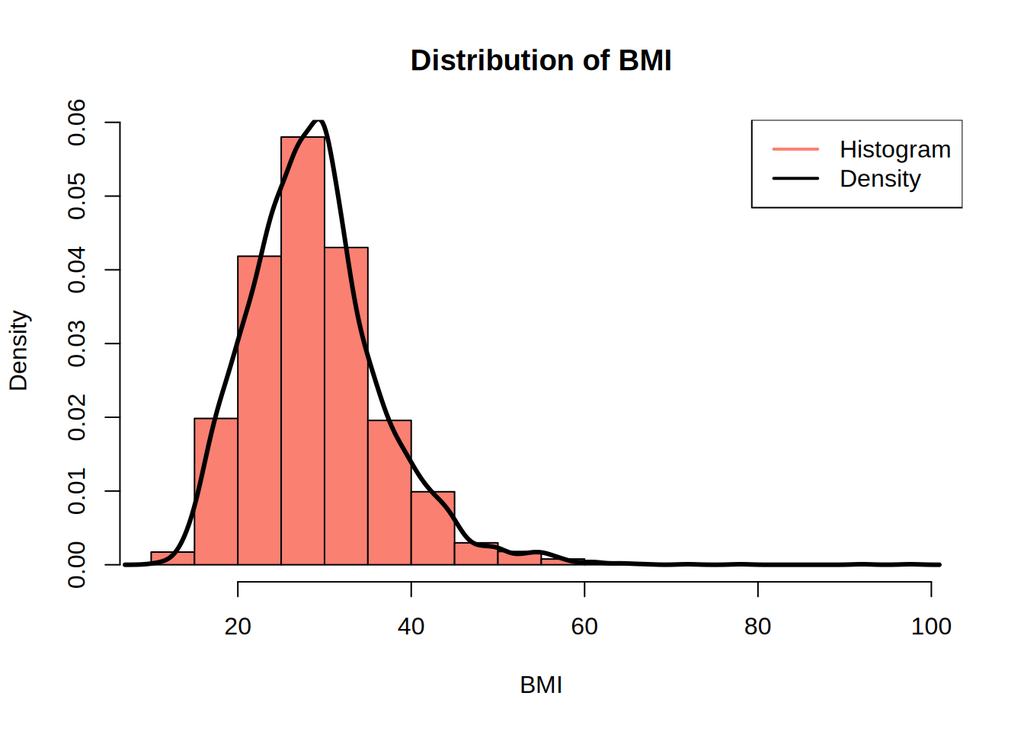

```r
hist(stroke_data$bmi, main = "Distribution of BMI", xlab = "BMI", col = "salmon", breaks = 20,prob=TRUE)
lines(density(stroke_data$bmi), col = "black", main = "BMI Distribution",lwd=3)
legend("topright", legend = c("Histogram", "Density"), col = c("salmon", "black"), lwd = 2)
```

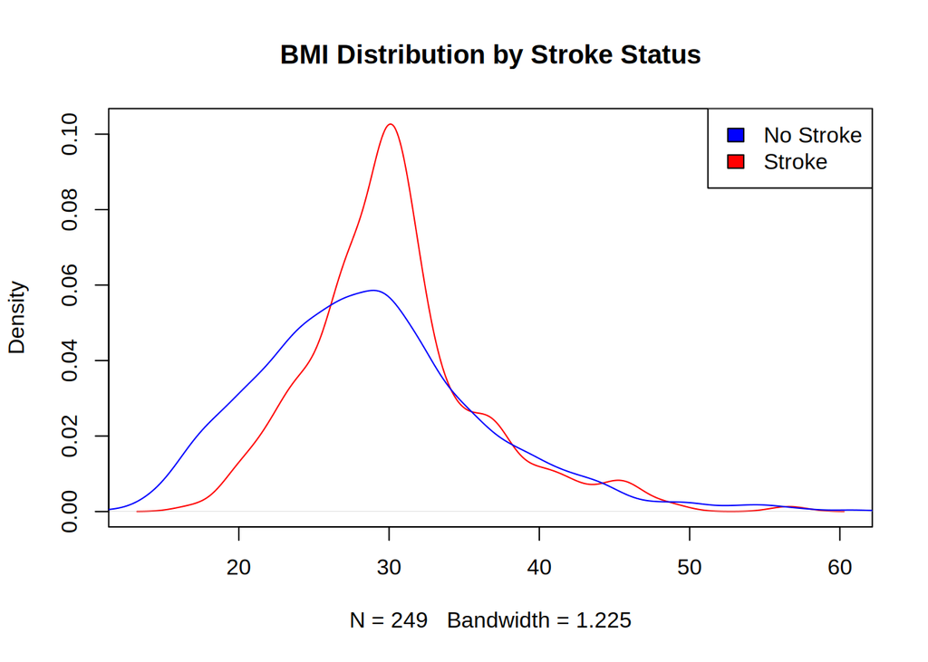

```r
plot(density(stroke_data$bmi[stroke_data$stroke == 1]), col = "red", main = "BMI Distribution by Stroke Status")
lines(density(stroke_data$bmi[stroke_data$stroke == 0]), col = "blue")
legend("topright", legend = c("No Stroke","Stroke"), fill = c("blue", "red"))
```

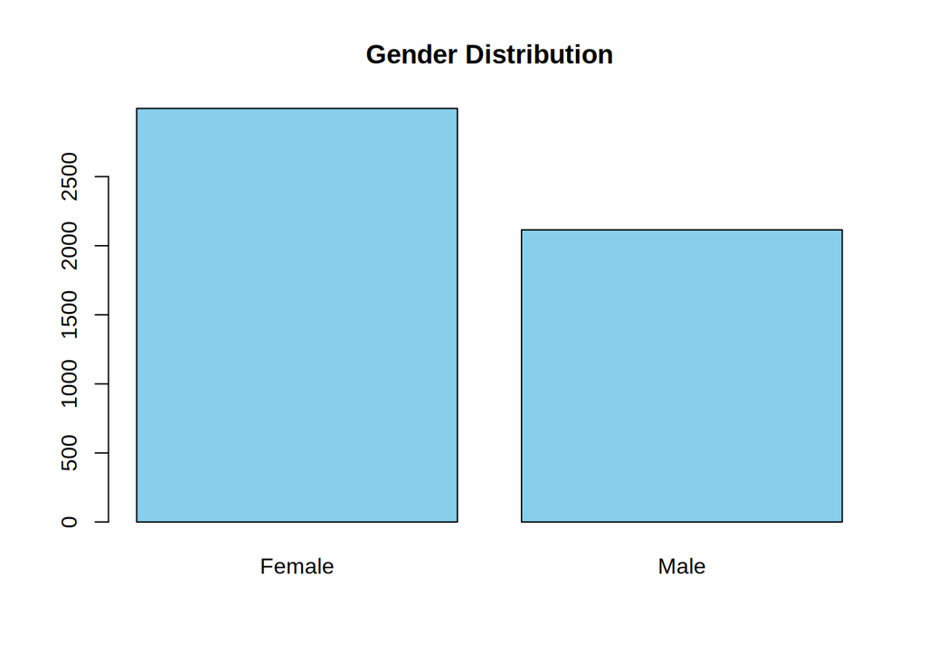

```r
barplot(table(stroke_data$gender), main = "Gender Distribution", col = "skyblue")
```

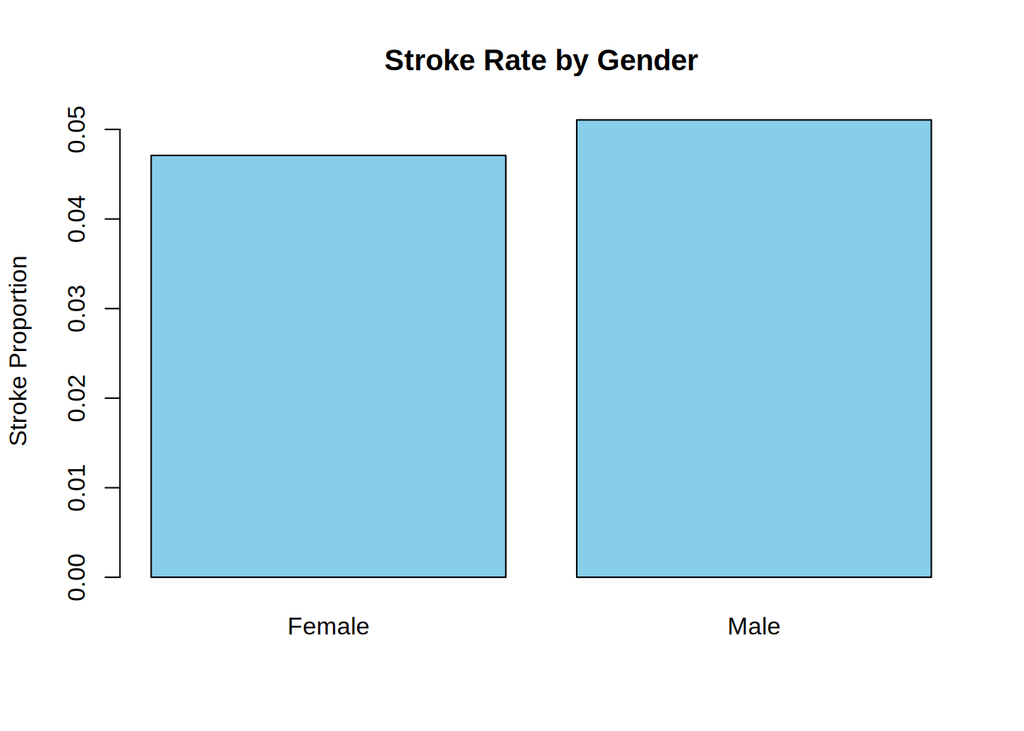

```r
gender_stroke = prop.table(table(stroke_data$gender, stroke_data$stroke), margin = 1)
barplot(gender_stroke[, 2], col = "skyblue", main = "Stroke Rate by Gender", ylab = "Stroke Proportion")
```

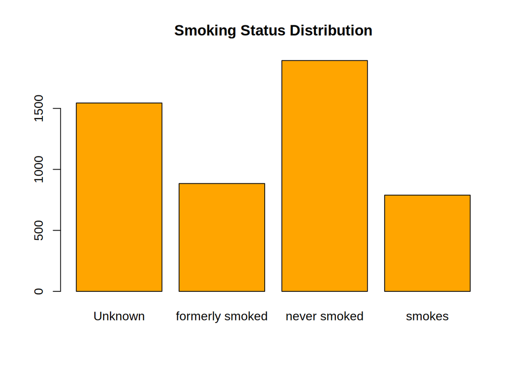

```r
barplot(table(stroke_data$smoking_status), main = "Smoking Status Distribution", col = "orange")
```

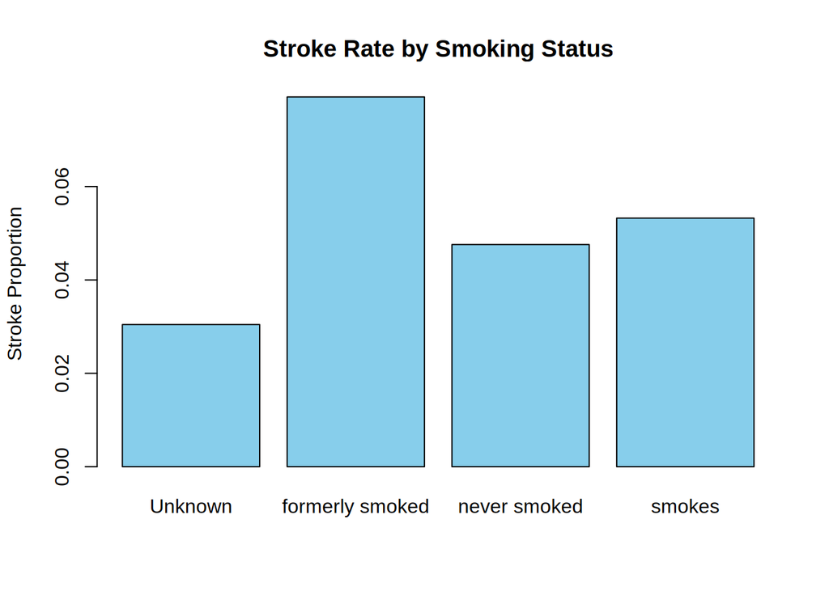

```r
smoke_stroke = prop.table(table(stroke_data$smoking_status, stroke_data$stroke), margin = 1)
barplot(smoke_stroke[, 2], col = "skyblue", main = "Stroke Rate by Smoking Status", ylab = "Stroke Proportion")
```

Former smokers have higher stroke rates.

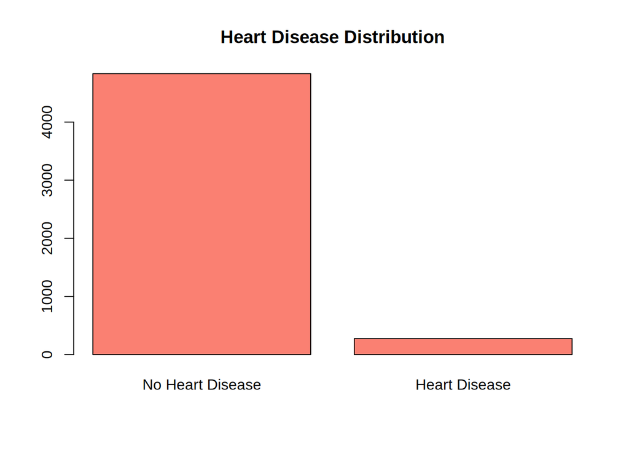

```r
barplot(table(stroke_data$heart_disease),names.arg = c("No Heart Disease", "Heart Disease"), main = "Heart Disease Distribution", col = "salmon")
```

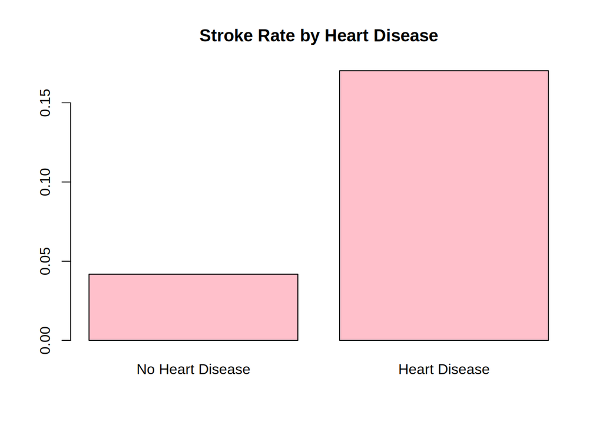

```r
hd_stroke = prop.table(table(stroke_data$heart_disease, stroke_data$stroke), margin = 1)
barplot(hd_stroke[, 2], names.arg = c("No Heart Disease", "Heart Disease"), col = "pink", main = "Stroke Rate by Heart Disease")
```

Heart disease increases stroke risk.

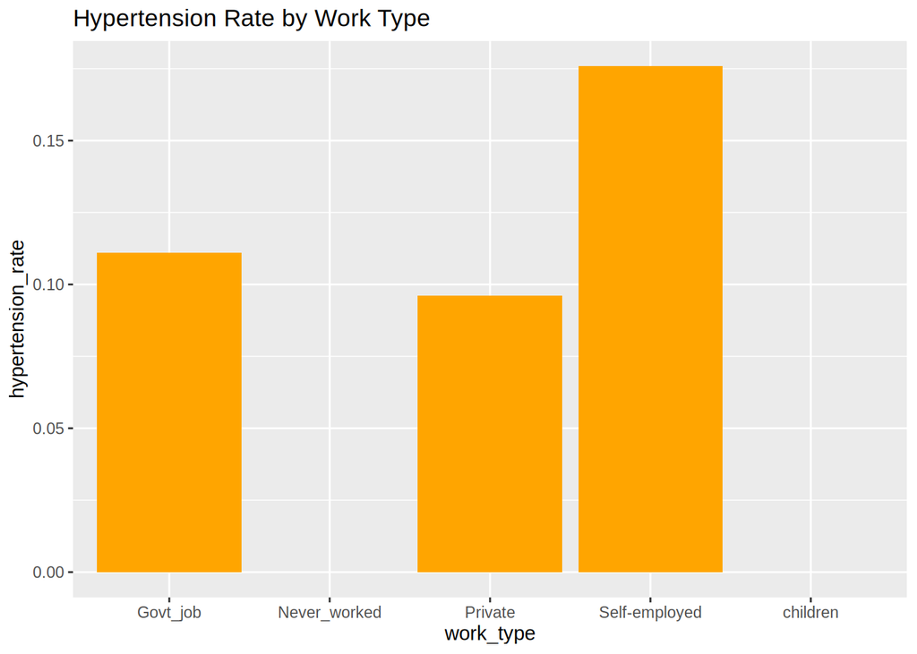

```r
stroke_data %>%
  group_by(work_type) %>%
  summarise(hypertension_rate = mean(hypertension)) %>%
  ggplot(aes(work_type, hypertension_rate)) +
  geom_col(fill = "orange") +
  labs(title = "Hypertension Rate by Work Type")
```

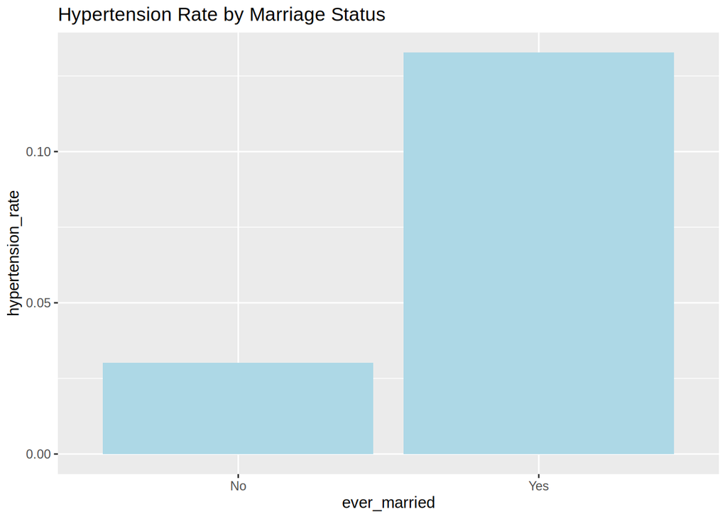

```r
stroke_data %>%
  group_by(ever_married) %>%
  summarise(hypertension_rate = mean(hypertension)) %>%
  ggplot(aes(ever_married, hypertension_rate)) +
  geom_col(fill = "lightblue") +
  labs(title = "Hypertension Rate by Marriage Status")
```

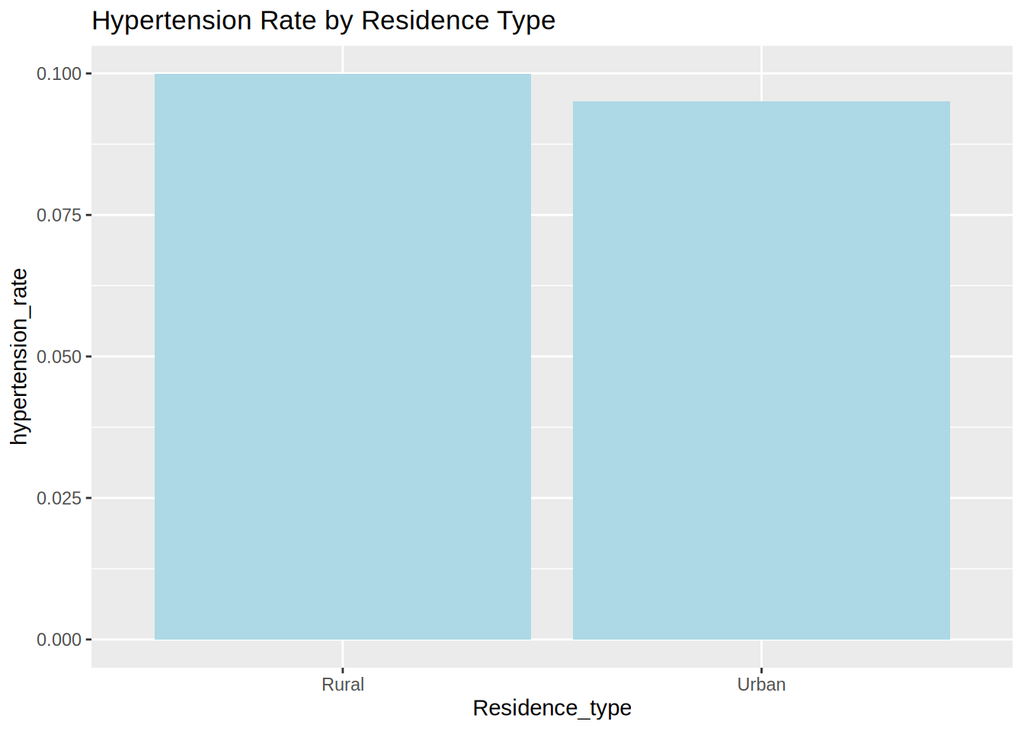

```r
stroke_data %>%
  group_by(Residence_type) %>%
  summarise(hypertension_rate = mean(hypertension)) %>%
  ggplot(aes(Residence_type, hypertension_rate)) +
  geom_col(fill = "lightblue") +
  labs(title = "Hypertension Rate by Residence Type")
```

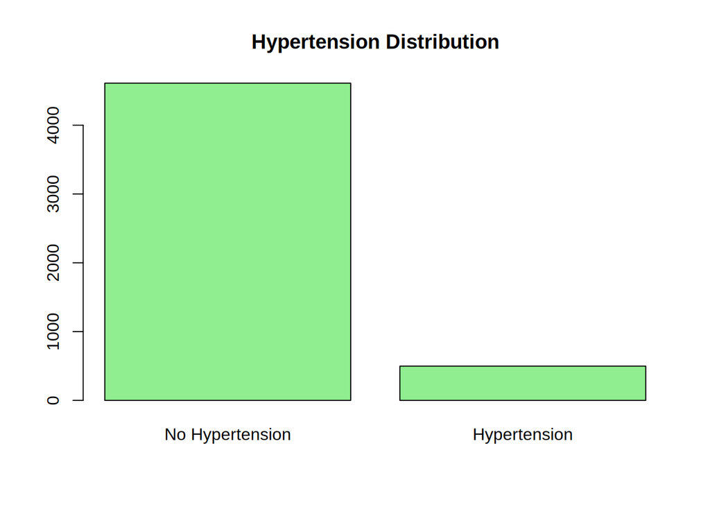

```r
barplot(table(stroke_data$hypertension),names.arg = c("No Hypertension", "Hypertension"), main = "Hypertension Distribution", col = "lightgreen")
```

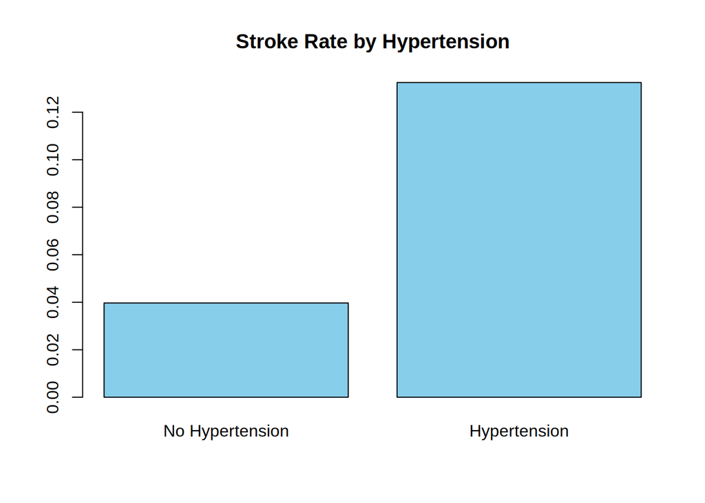

```r
hypertension_stroke = prop.table(table(stroke_data$hypertension, stroke_data$stroke), margin = 1)
barplot(hypertension_stroke[, 2], names.arg = c("No Hypertension", "Hypertension"), col = "skyblue", main = "Stroke Rate by Hypertension")
```

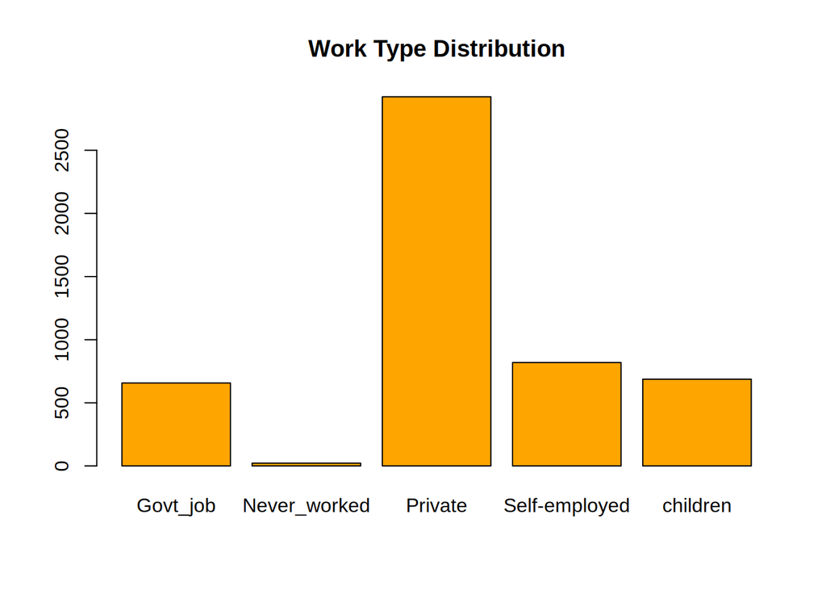

```r
barplot(table(stroke_data$work_type), main = "Work Type Distribution", col = "orange")
```

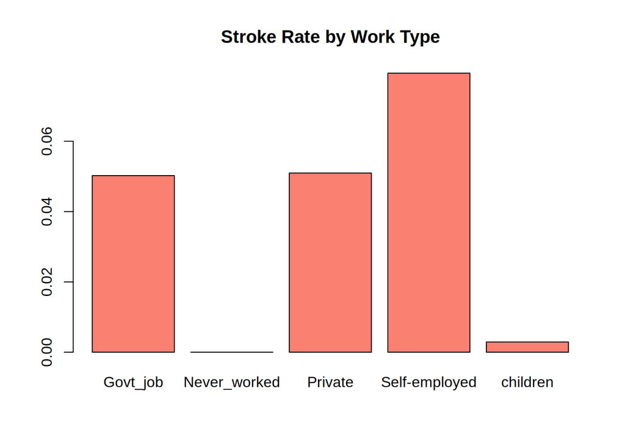

```r
res_stroke = prop.table(table(stroke_data$work_type, stroke_data$stroke), margin = 1)
barplot(res_stroke[, 2], col = "salmon", main = "Stroke Rate by Work Type")
```

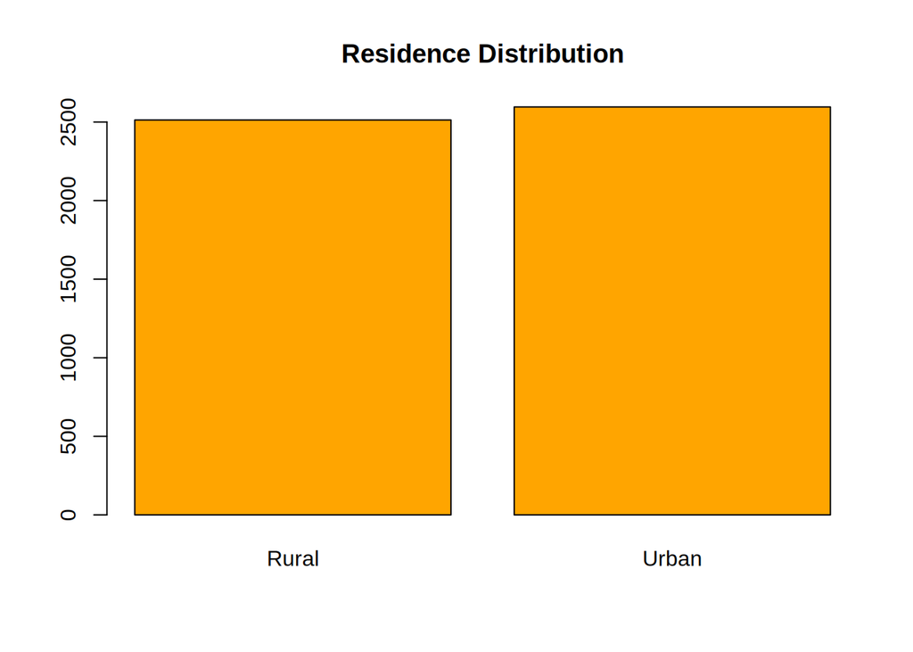

```r
barplot(table(stroke_data$Residence_type), main = "Residence Distribution", col = "orange")
```

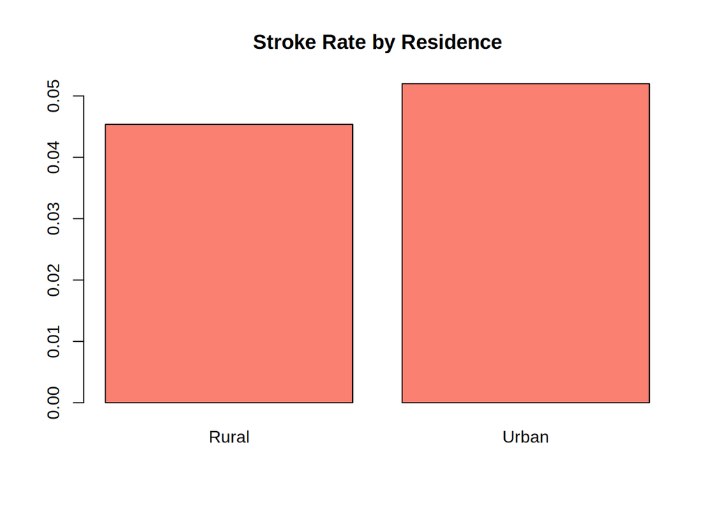

```r
res_stroke = prop.table(table(stroke_data$Residence_type, stroke_data$stroke), margin = 1)
barplot(res_stroke[, 2], names.arg = c("Rural", "Urban"), col = "salmon", main = "Stroke Rate by Residence")
```

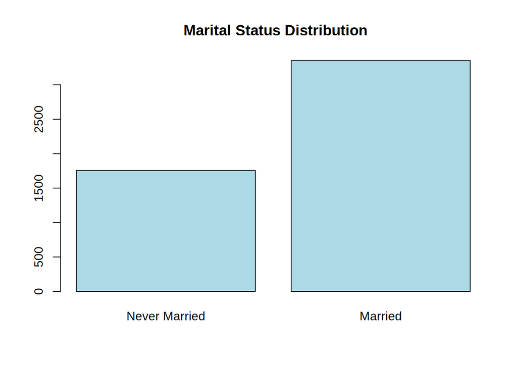

```r
barplot(table(stroke_data$ever_married),names.arg = c("Never Married", "Married"), main = " Marital Status Distribution", col = "lightblue")
```

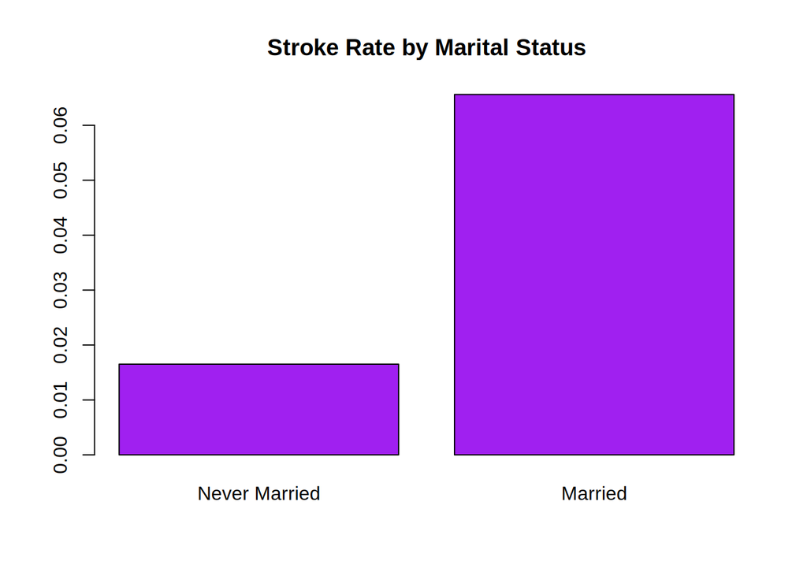

```r
married_stroke = prop.table(table(stroke_data$ever_married, stroke_data$stroke), margin = 1)
barplot(married_stroke[, 2], names.arg = c("Never Married", "Married"), col = "purple", main = "Stroke Rate by Marital Status")
```

```r
numerical_vars = stroke_data[, c("age", "avg_glucose_level", "bmi")]
numerical_vars$stroke = stroke_data$stroke
cor_matrix = cor(numerical_vars, use = "complete.obs")
print(cor_matrix)
```

```
##                         age avg_glucose_level        bmi     stroke
## age               1.0000000         0.2383228 0.33519923 0.24523876
## avg_glucose_level 0.2383228         1.0000000 0.17267144 0.13199119
## bmi               0.3351992         0.1726714 1.00000000 0.04332213
## stroke            0.2452388         0.1319912 0.04332213 1.00000000
```